63%

63%

50%

58%

63%

58%

58%

46%

63%

29%

46%

42%

54%

46%

33%

33%

71%

21%

38%

33%

46%

58%

13%

42%

13%

29%

29%

29%

17%

USMLEStep1score

Lettersofrecommendationinthespecialty

USMLEStep2CKscore

PersonalStatement

MedicalStudentPerformanceEvaluation(MSPE/Dean'sLetter)

Perceivedcommitmenttospecialty

Gradesinrequiredclerkships

Auditionelective/rotationwithinyourdepartment

AnyfailedattemptinUSMLE

Classranking/quartile

Personalpriorknowledgeoftheapplicant

Leadershipqualities

Gradesinclerkshipindesiredspecialty

Evidenceofprofessionalismandethics

Perceivedinterestinprogram

PassingUSMLEStep2CS

Otherlifeexperience

COMLEX‐USALevel1score*

AlphaOmegaAlpha(AOA)membership

AnyfailedattemptinCOMLEX‐USA*

Volunteer/extracurricularexperiences

COMLEX‐USALevel2ClinicalEvaluation(CE)score*

Consistencyofgrades

Awardsorspecialhonorsinclinicalclerkships

Graduateofhighly‐regardedmedical(MD/DO)school

Evidenceofcontinuousmedicaleducationwithoutgaps

GoldHumanismHonorSociety(GHHS)membership

Awardsorspecialhonorsinclerkshipindesiredspecialty

PassingCOMLEX‐USALevel2PerformanceEvaluation*

Demonstratedinvolvementandinterestinresearch

ApplicantwasflaggedwithMatchviolationbytheNRMP

Visastatus**

Awayrotationinyourspecialtyatanotherinstitution

Fluencyinlanguagespokenbyyourpatientpopulation

Interestinacademiccareer

Awardsorspecialhonorsinbasicsciences

USMLEStep3score

COMLEX‐USALevel3score*

NRMP Program Director Survey Results, 2020

101

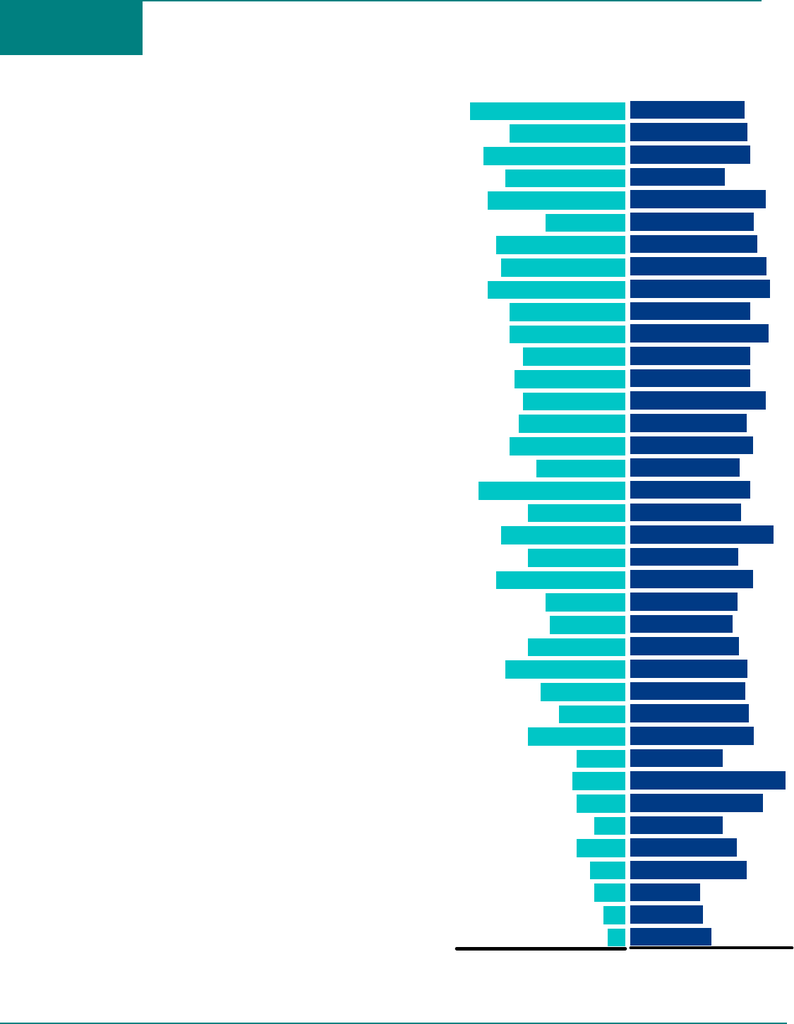

Figure P-1

Pediatrics

Percentage of Programs Citing Each Factor And Mean Importance Rating¹ for Each

Factor in Selecting Applicants to Interview

(N=38)

Avera

g

e Ratin

g

Percent Citin

g

Facto

r

¹ Ratings on a scale from 1 (not at all important) to 5 (very important).

* DO seniors/graduates only.

** International Medical Graduates only.

1

2

3 4

5

3.8

3.9

4.0

3.3

4.4

4.1

4.1

4.4

4.5

4.0

4.4

4.0

4.0

4.3

3.9

4.0

3.7

4.0

3.7

4.5

3.7

4.0

3.6

3.5

3.7

3.9

3.8

3.9

4.0

3.3

4.8

4.3

3.3

3.6

3.9

2.7

2.8

3.0

100% 50% 0%

92%

68%

84%

71%

82%

47%

76%

74%

82%

68%

68%

61%

66%

61%

63%

68%

53%

87%

58%

74%

58%

76%

47%

45%

58%

71%

50%

39%

58%

29%

32%

29%

18%

29%

21%

18%

13%

11%

USMLEStep1score

Lettersofrecommendationinthespecialty

USMLEStep2CKscore

PersonalStatement

MedicalStudentPerformanceEvaluation(MSPE/Dean'sLetter)

Perceivedcommitmenttospecialty

Gradesinrequiredclerkships

Auditionelective/rotationwithinyourdepartment

AnyfailedattemptinUSMLE

Classranking/quartile

Personalpriorknowledgeoftheapplicant

Leadershipqualities

Gradesinclerkshipindesiredspecialty

Evidenceofprofessionalismandethics

Perceivedinterestinprogram

PassingUSMLEStep2CS

Otherlifeexperience

COMLEX‐USALevel1score*

AlphaOmegaAlpha(AOA)membership

AnyfailedattemptinCOMLEX‐USA*

Volunteer/extracurricularexperiences

COMLEX‐USALevel2ClinicalEvaluation(CE)score*

Consistencyofgrades

Awardsorspecialhonorsinclinicalclerkships

Graduateofhighly‐regardedmedical(MD/DO)school

Evidenceofcontinuousmedicaleducationwithoutgaps

GoldHumanismHonorSociety(GHHS)membership

Awardsorspecialhonorsinclerkshipindesiredspecialty

PassingCOMLEX‐USALevel2PerformanceEvaluation*

Demonstratedinvolvementandinterestinresearch

ApplicantwasflaggedwithMatchviolationbytheNRMP

Visastatus**

Awayrotationinyourspecialtyatanotherinstitution

Fluencyinlanguagespokenbyyourpatientpopulation

Interestinacademiccareer

Awardsorspecialhonorsinbasicsciences

USMLEStep3score

COMLEX‐USALevel3score*

NRMP Program Director Survey Results, 2020

108

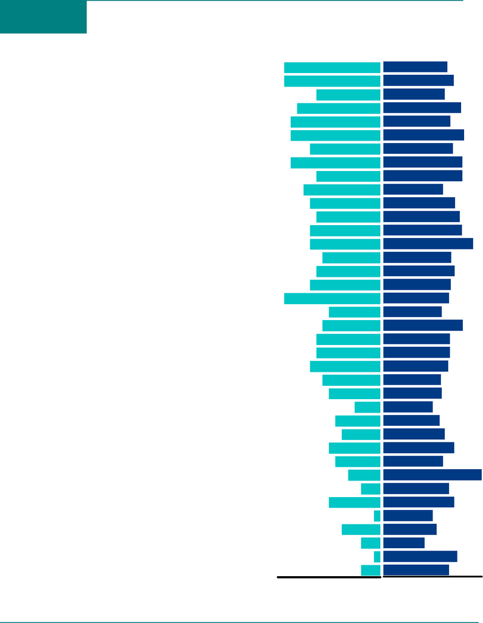

Figure PMR-1

Physical Medicine and Rehabilitation

Percentage of Programs Citing Each Factor And Mean Importance Rating¹ for Each

Factor in Selecting Applicants to Interview

(N=16)

Avera

g

e Ratin

g

Percent Citin

g

Facto

r

¹ Ratings on a scale from 1 (not at all important) to 5 (very important).

* DO seniors/graduates only.

** International Medical Graduates only.

1

2

3 4

5

3.6

3.9

3.5

4.2

3.7

4.3

3.8

4.2

4.2

3.4

3.9

4.1

4.2

4.6

3.8

3.9

3.7

3.7

3.4

4.2

3.7

3.7

3.6

3.3

3.4

3.0

3.3

3.5

3.9

3.4

5.0

3.7

3.9

3.0

3.2

2.7

4.0

3.7

100% 50% 0%

94%

94%

63%

81%

88%

88%

69%

88%

63%

75%

69%

63%

69%

69%

56%

63%

69%

94%

50%

56%

63%

63%

69%

56%

50%

25%

44%

38%

50%

44%

31%

19%

50%

6%

38%

19%

6%

19%

USMLEStep1score

Lettersofrecommendationinthespecialty

USMLEStep2CKscore

PersonalStatement

MedicalStudentPerformanceEvaluation(MSPE/Dean'sLetter)

Perceivedcommitmenttospecialty

Gradesinrequiredclerkships

Auditionelective/rotationwithinyourdepartment

AnyfailedattemptinUSMLE

Classranking/quartile

Personalpriorknowledgeoftheapplicant

Leadershipqualities

Gradesinclerkshipindesiredspecialty

Evidenceofprofessionalismandethics

Perceivedinterestinprogram

PassingUSMLEStep2CS

Otherlifeexperience

COMLEX‐USALevel1score*

AlphaOmegaAlpha(AOA)membership

AnyfailedattemptinCOMLEX‐USA*

Volunteer/extracurricularexperiences

COMLEX‐USALevel2ClinicalEvaluation(CE)score*

Consistencyofgrades

Awardsorspecialhonorsinclinicalclerkships

Graduateofhighly‐regardedmedical(MD/DO)school

Evidenceofcontinuousmedicaleducationwithoutgaps

GoldHumanismHonorSociety(GHHS)membership

Awardsorspecialhonorsinclerkshipindesiredspecialty

PassingCOMLEX‐USALevel2PerformanceEvaluation*

Demonstratedinvolvementandinterestinresearch

ApplicantwasflaggedwithMatchviolationbytheNRMP

Visastatus**

Awayrotationinyourspecialtyatanotherinstitution

Fluencyinlanguagespokenbyyourpatientpopulation

Interestinacademiccareer

Awardsorspecialhonorsinbasicsciences

USMLEStep3score

COMLEX‐USALevel3score*

NRMP Program Director Survey Results, 2020

115

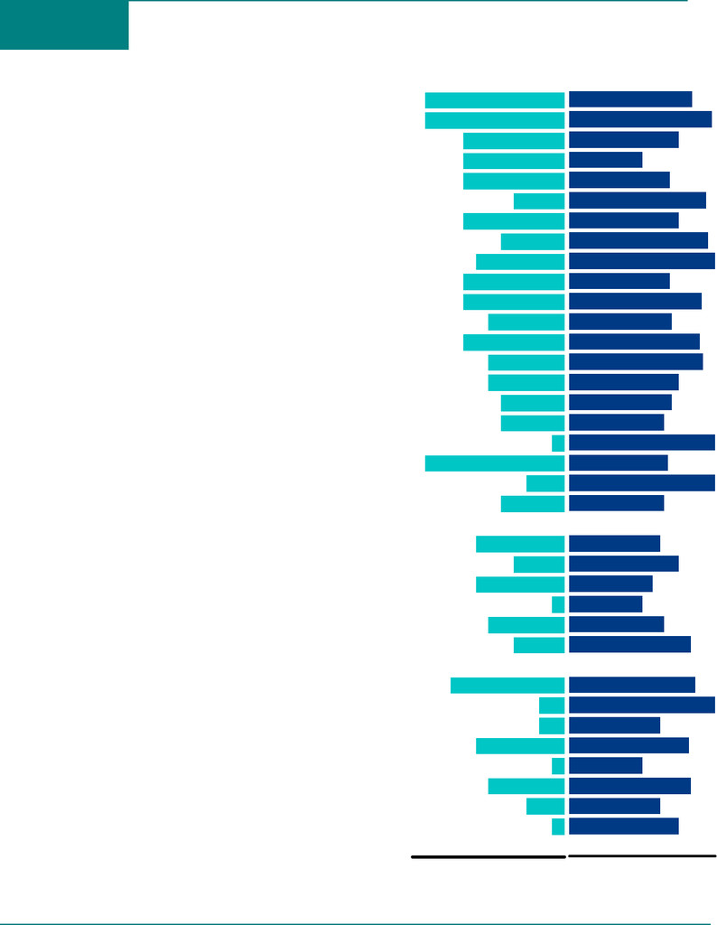

Figure PS-1

Plastic Surgery

Percentage of Programs Citing Each Factor And Mean Importance Rating¹ for Each

Factor in Selecting Applicants to Interview

(N=12)

Avera

g

e Ratin

g

Percent Citin

g

Facto

r

¹ Ratings on a scale from 1 (not at all important) to 5 (very important).

* DO seniors/graduates only.

** International Medical Graduates only.

1

2

3 4

5

4.4

4.9

4.0

3.0

3.8

4.8

4.0

4.8

5.0

3.8

4.6

3.8

4.6

4.7

4.0

3.8

3.6

5.0

3.7

5.0

3.6

3.5

4.0

3.3

3.0

3.6

4.3

4.4

5.0

3.5

4.3

3.0

4.3

3.5

4.0

100% 50% 0%

92%

92%

67%

67%

67%

33%

67%

42%

58%

67%

67%

50%

67%

50%

50%

42%

42%

8%

92%

25%

42%

0%

58%

33%

58%

8%

50%

33%

0%

75%

17%

17%

58%

8%

50%

25%

8%

0%

USMLEStep1score

Lettersofrecommendationinthespecialty

USMLEStep2CKscore

PersonalStatement

MedicalStudentPerformanceEvaluation(MSPE/Dean'sLetter)

Perceivedcommitmenttospecialty

Gradesinrequiredclerkships

Auditionelective/rotationwithinyourdepartment

AnyfailedattemptinUSMLE

Classranking/quartile

Personalpriorknowledgeoftheapplicant

Leadershipqualities

Gradesinclerkshipindesiredspecialty

Evidenceofprofessionalismandethics

Perceivedinterestinprogram

PassingUSMLEStep2CS

Otherlifeexperience

COMLEX‐USALevel1score*

AlphaOmegaAlpha(AOA)membership

AnyfailedattemptinCOMLEX‐USA*

Volunteer/extracurricularexperiences

COMLEX‐USALevel2ClinicalEvaluation(CE)score*

Consistencyofgrades

Awardsorspecialhonorsinclinicalclerkships

Graduateofhighly‐regardedmedical(MD/DO)school

Evidenceofcontinuousmedicaleducationwithoutgaps

GoldHumanismHonorSociety(GHHS)membership

Awardsorspecialhonorsinclerkshipindesiredspecialty

PassingCOMLEX‐USALevel2PerformanceEvaluation*

Demonstratedinvolvementandinterestinresearch

ApplicantwasflaggedwithMatchviolationbytheNRMP

Visastatus**

Awayrotationinyourspecialtyatanotherinstitution

Fluencyinlanguagespokenbyyourpatientpopulation

Interestinacademiccareer

Awardsorspecialhonorsinbasicsciences

USMLEStep3score

COMLEX‐USALevel3score*

NRMP Program Director Survey Results, 2020

122

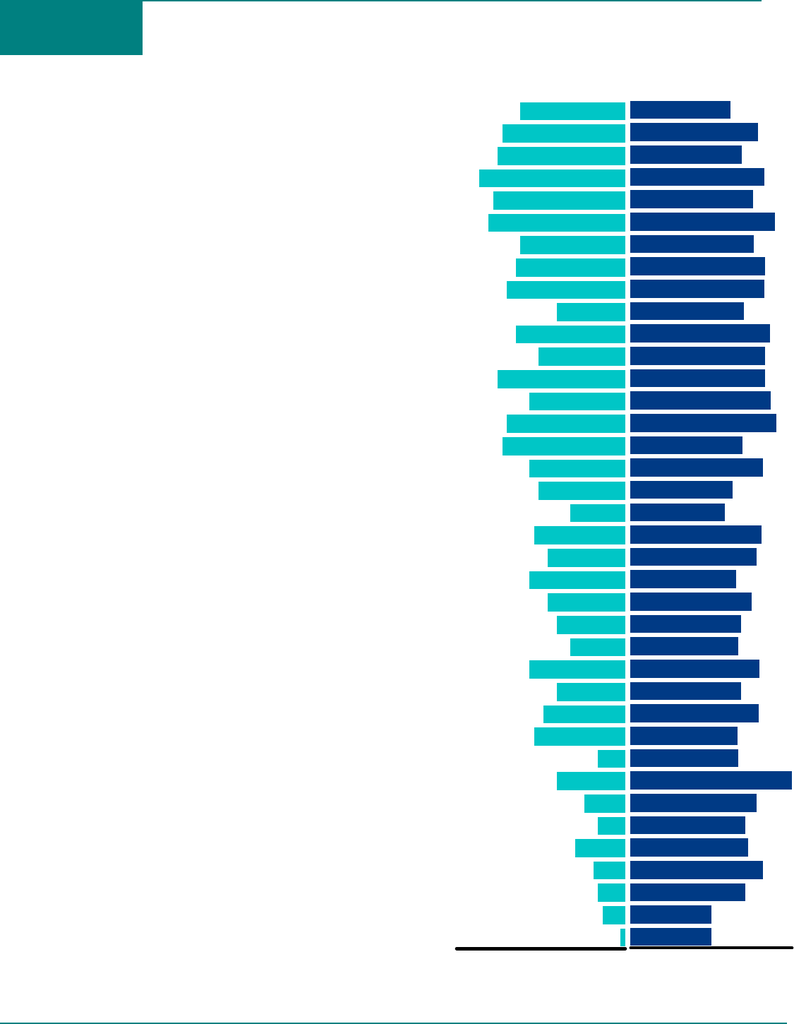

Figure PSY-1

Psychiatry

Percentage of Programs Citing Each Factor And Mean Importance Rating¹ for Each

Factor in Selecting Applicants to Interview

(N=37)

Avera

g

e Ratin

g

Percent Citin

g

Facto

r

¹ Ratings on a scale from 1 (not at all important) to 5 (very important).

* DO seniors/graduates only.

** International Medical Graduates only.

1

2

3 4

5

3.5

4.1

3.8

4.3

4.0

4.6

4.0

4.3

4.3

3.8

4.5

4.3

4.3

4.5

4.6

3.8

4.3

3.5

3.3

4.3

4.1

3.6

4.0

3.7

3.7

4.2

3.7

4.2

3.6

3.7

5.0

4.1

3.8

3.9

4.3

3.8

3.0

3.0

100% 50% 0%

62%

73%

76%

86%

78%

81%

62%

65%

70%

41%

65%

51%

76%

57%

70%

73%

57%

51%

32%

54%

46%

57%

46%

41%

32%

57%

41%

49%

54%

16%

41%

24%

16%

30%

19%

16%

14%

3%

USMLEStep1score

Lettersofrecommendationinthespecialty

USMLEStep2CKscore

PersonalStatement

MedicalStudentPerformanceEvaluation(MSPE/Dean'sLetter)

Perceivedcommitmenttospecialty

Gradesinrequiredclerkships

Auditionelective/rotationwithinyourdepartment

AnyfailedattemptinUSMLE

Classranking/quartile

Personalpriorknowledgeoftheapplicant

Leadershipqualities

Gradesinclerkshipindesiredspecialty

Evidenceofprofessionalismandethics

Perceivedinterestinprogram

PassingUSMLEStep2CS

Otherlifeexperience

COMLEX‐USALevel1score*

AlphaOmegaAlpha(AOA)membership

AnyfailedattemptinCOMLEX‐USA*

Volunteer/extracurricularexperiences

COMLEX‐USALevel2ClinicalEvaluation(CE)score*

Consistencyofgrades

Awardsorspecialhonorsinclinicalclerkships

Graduateofhighly‐regardedmedical(MD/DO)school

Evidenceofcontinuousmedicaleducationwithoutgaps

GoldHumanismHonorSociety(GHHS)membership

Awardsorspecialhonorsinclerkshipindesiredspecialty

PassingCOMLEX‐USALevel2PerformanceEvaluation*

Demonstratedinvolvementandinterestinresearch

ApplicantwasflaggedwithMatchviolationbytheNRMP

Visastatus**

Awayrotationinyourspecialtyatanotherinstitution

Fluencyinlanguagespokenbyyourpatientpopulation

Interestinacademiccareer

Awardsorspecialhonorsinbasicsciences

USMLEStep3score

COMLEX‐USALevel3score*

NRMP Program Director Survey Results, 2020

129

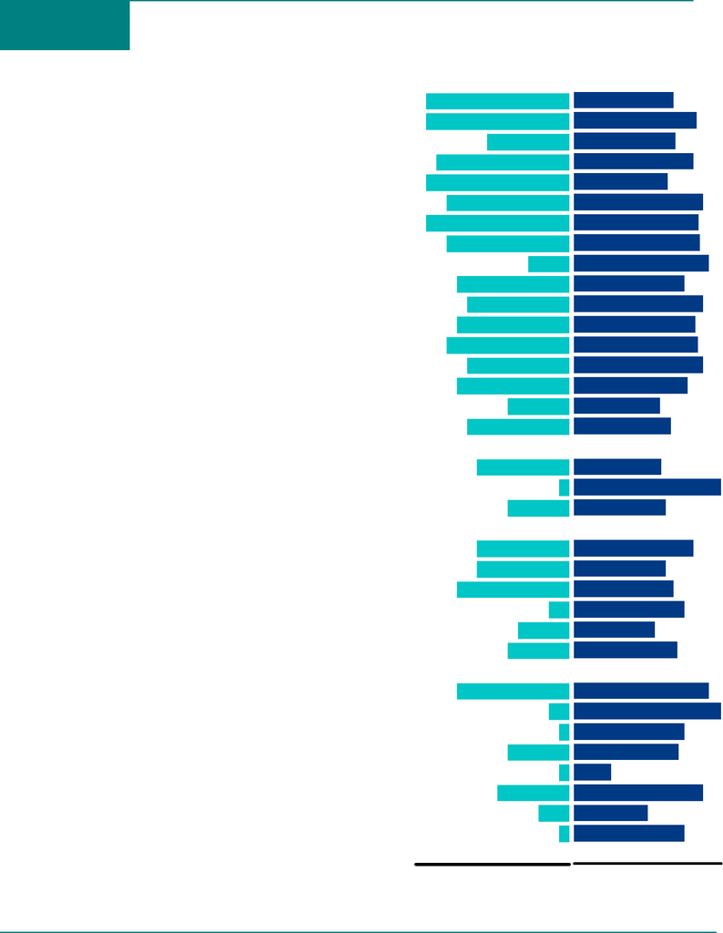

Figure RO-1

Radiation Oncology

Percentage of Programs Citing Each Factor And Mean Importance Rating¹ for Each

Factor in Selecting Applicants to Interview

(N=15)

Avera

g

e Ratin

g

Percent Citin

g

Facto

r

¹ Ratings on a scale from 1 (not at all important) to 5 (very important).

* DO seniors/graduates only.

** International Medical Graduates only.

1

2

3 4

5

3.7

4.3

3.8

4.3

3.5

4.5

4.4

4.4

4.7

4.0

4.5

4.3

4.4

4.5

4.1

3.3

3.6

3.4

5.0

3.5

4.3

3.5

3.7

4.0

3.2

3.8

4.7

5.0

4.0

3.8

2.0

4.5

3.0

4.0

100% 50% 0%

93%

93%

53%

87%

93%

80%

93%

80%

27%

73%

67%

73%

80%

67%

73%

40%

67%

0%

60%

7%

40%

0%

60%

60%

73%

13%

33%

40%

0%

73%

13

%

7%

40%

7%

47%

20%

7%

0%

USMLEStep1score

Lettersofrecommendationinthespecialty

USMLEStep2CKscore

PersonalStatement

MedicalStudentPerformanceEvaluation(MSPE/Dean'sLetter)

Perceivedcommitmenttospecialty

Gradesinrequiredclerkships

Auditionelective/rotationwithinyourdepartment

AnyfailedattemptinUSMLE

Classranking/quartile

Personalpriorknowledgeoftheapplicant

Leadershipqualities

Gradesinclerkshipindesiredspecialty

Evidenceofprofessionalismandethics

Perceivedinterestinprogram

PassingUSMLEStep2CS

Otherlifeexperience

COMLEX‐USALevel1score*

AlphaOmegaAlpha(AOA)membership

AnyfailedattemptinCOMLEX‐USA*

Volunteer/extracurricularexperiences

COMLEX‐USALevel2ClinicalEvaluation(CE)score*

Consistencyofgrades

Awardsorspecialhonorsinclinicalclerkships

Graduateofhighly‐regardedmedical(MD/DO)school

Evidenceofcontinuousmedicaleducationwithoutgaps

GoldHumanismHonorSociety(GHHS)membership

Awardsorspecialhonorsinclerkshipindesiredspecialty

PassingCOMLEX‐USALevel2PerformanceEvaluation*

Demonstratedinvolvementandinterestinresearch

ApplicantwasflaggedwithMatchviolationbytheNRMP

Visastatus**

Awayrotationinyourspecialtyatanotherinstitution

Fluencyinlanguagespokenbyyourpatientpopulation

Interestinacademiccareer

Awardsorspecialhonorsinbasicsciences

USMLEStep3score

COMLEX‐USALevel3score*

NRMP Program Director Survey Results, 2020

136

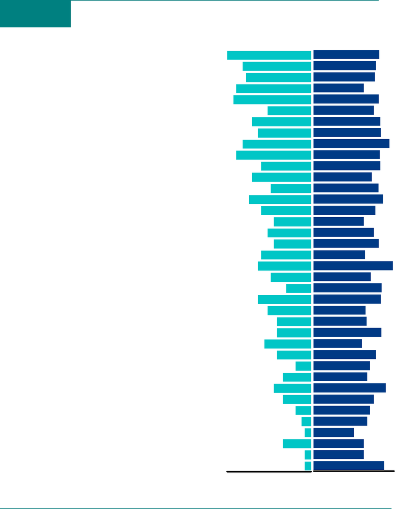

Figure RD-1

Radiology-Diagnostic

Percentage of Programs Citing Each Factor And Mean Importance Rating¹ for Each

Factor in Selecting Applicants to Interview

(N=27)

Avera

g

e Ratin

g

Percent Citin

g

Facto

r

¹ Ratings on a scale from 1 (not at all important) to 5 (very important).

* DO seniors/graduates only.

** International Medical Graduates only.

1

2

3 4

5

4.3

4.1

4.0

3.5

4.2

4.0

4.3

4.4

4.8

4.3

4.3

3.9

4.2

4.5

4.1

3.5

4.0

4.3

3.6

4.9

3.8

4.4

4.4

3.6

3.6

4.4

3.4

4.1

3.8

3.7

4.6

4.0

3.8

3.7

3.0

3.5

3.5

4.5

100% 50% 0%

100%

81%

78%

89%

93%

52%

70%

63%

81%

89%

59%

70%

48%

74%

59%

44%

52%

44%

59%

63%

48%

30%

63%

52%

41%

41%

56%

41%

19%

33%

44%

33%

19%

11%

7%

33%

7%

7%

USMLEStep1score

Lettersofrecommendationinthespecialty

USMLEStep2CKscore

PersonalStatement

MedicalStudentPerformanceEvaluation(MSPE/Dean'sLetter)

Perceivedcommitmenttospecialty

Gradesinrequiredclerkships

Auditionelective/rotationwithinyourdepartment

AnyfailedattemptinUSMLE

Classranking/quartile

Personalpriorknowledgeoftheapplicant

Leadershipqualities

Gradesinclerkshipindesiredspecialty

Evidenceofprofessionalismandethics

Perceivedinterestinprogram

PassingUSMLEStep2CS

Otherlifeexperience

COMLEX‐USALevel1score*

AlphaOmegaAlpha(AOA)membership

AnyfailedattemptinCOMLEX‐USA*

Volunteer/extracurricularexperiences

COMLEX‐USALevel2ClinicalEvaluation(CE)score*

Consistencyofgrades

Awardsorspecialhonorsinclinicalclerkships

Graduateofhighly‐regardedmedical(MD/DO)school

Evidenceofcontinuousmedicaleducationwithoutgaps

GoldHumanismHonorSociety(GHHS)membership

Awardsorspecialhonorsinclerkshipindesiredspecialty

PassingCOMLEX‐USALevel2PerformanceEvaluation*

Demonstratedinvolvementandinterestinresearch

ApplicantwasflaggedwithMatchviolationbytheNRMP

Visastatus**

Awayrotationinyourspecialtyatanotherinstitution

Fluencyinlanguagespokenbyyourpatientpopulation

Interestinacademiccareer

Awardsorspecialhonorsinbasicsciences

USMLEStep3score

COMLEX‐USALevel3score*

NRMP Program Director Survey Results, 2020

143

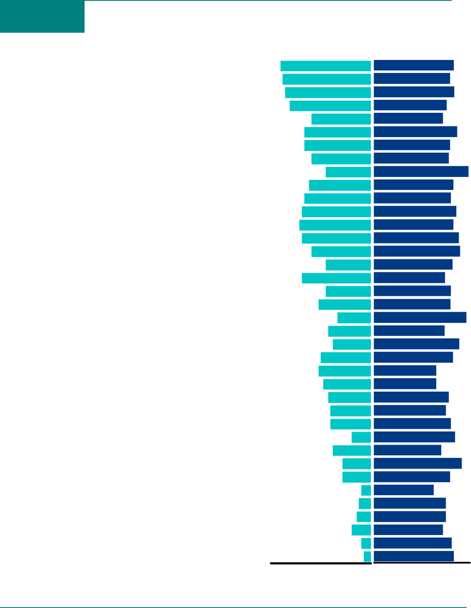

Figure GS-1

Surgery

Percentage of Programs Citing Each Factor And Mean Importance Rating¹ for Each

Factor in Selecting Applicants to Interview

(N=42)

Avera

g

e Ratin

g

Percent Citin

g

Facto

r

¹ Ratings on a scale from 1 (not at all important) to 5 (very important).

* DO seniors/graduates only.

** International Medical Graduates only.

1

2

3 4

5

4.3

4.2

4.3

4.0

3.9

4.5

4.2

4.1

4.9

4.3

4.2

4.4

4.3

4.5

4.6

4.3

4.0

4.2

4.2

4.9

3.9

4.6

4.3

3.6

3.6

4.1

4.0

4.2

4.4

3.8

4.7

4.2

3.5

4.0

4.0

3.9

4.3

4.3

100% 50% 0%

90%

88%

86%

81%

60%

67%

67%

60%

45%

62%

67%

69%

71%

69%

60%

45%

69%

45%

52%

33%

43%

38%

50%

52%

48%

43%

40%

40%

19%

38%

29%

29%

10%

12%

14%

19%

10%

7%

USMLEStep1score

Lettersofrecommendationinthespecialty

USMLEStep2CKscore

PersonalStatement

MedicalStudentPerformanceEvaluation(MSPE/Dean'sLetter)

Perceivedcommitmenttospecialty

Gradesinrequiredclerkships

Auditionelective/rotationwithinyourdepartment

AnyfailedattemptinUSMLE

Classranking/quartile

Personalpriorknowledgeoftheapplicant

Leadershipqualities

Gradesinclerkshipindesiredspecialty

Evidenceofprofessionalismandethics

Perceivedinterestinprogram

PassingUSMLEStep2CS

Otherlifeexperience

COMLEX‐USALevel1score*

AlphaOmegaAlpha(AOA)membership

AnyfailedattemptinCOMLEX‐USA*

Volunteer/extracurricularexperiences

COMLEX‐USALevel2ClinicalEvaluation(CE)score*

Consistencyofgrades

Awardsorspecialhonorsinclinicalclerkships

Graduateofhighly‐regardedmedical(MD/DO)school

Evidenceofcontinuousmedicaleducationwithoutgaps

GoldHumanismHonorSociety(GHHS)membership

Awardsorspecialhonorsinclerkshipindesiredspecialty

PassingCOMLEX‐USALevel2PerformanceEvaluation*

Demonstratedinvolvementandinterestinresearch

ApplicantwasflaggedwithMatchviolationbytheNRMP

Visastatus**

Awayrotationinyourspecialtyatanotherinstitution

Fluencyinlanguagespokenbyyourpatientpopulation

Interestinacademiccareer

Awardsorspecialhonorsinbasicsciences

USMLEStep3score

COMLEX‐USALevel3score*

NRMP Program Director Survey Results, 2020

150

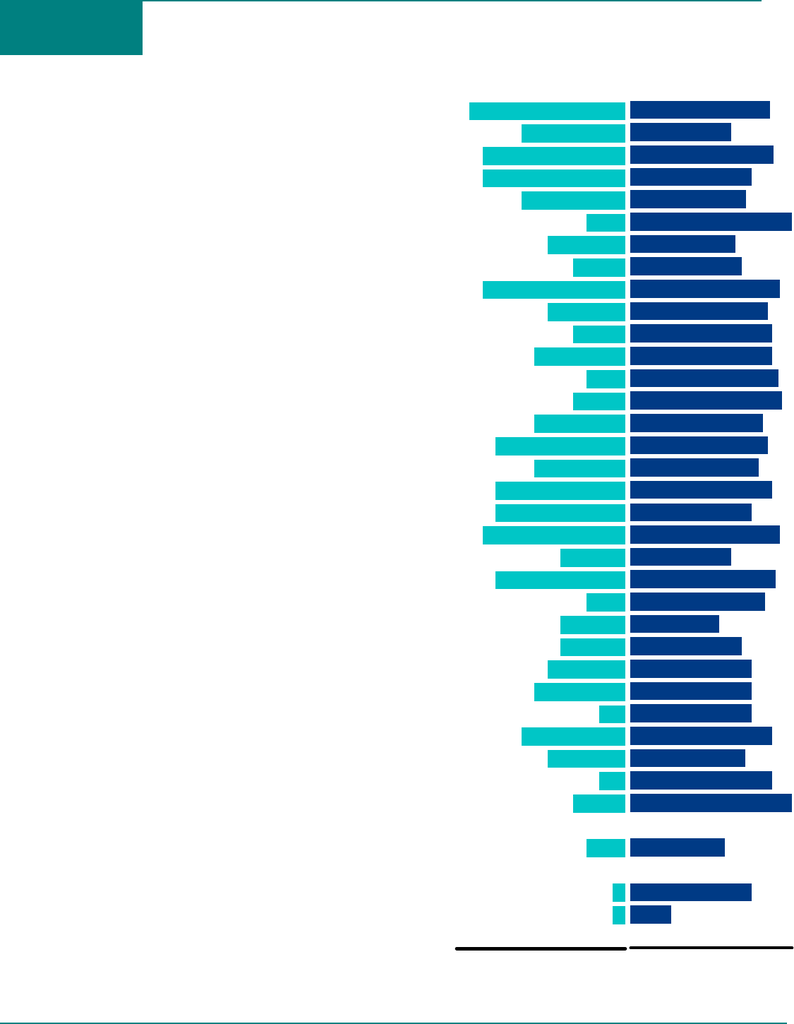

Figure TY-1

Transitional Year

Percentage of Programs Citing Each Factor And Mean Importance Rating¹ for Each

Factor in Selecting Applicants to Interview

(N=13)

Avera

g

e Ratin

g

Percent Citin

g

Facto

r

¹ Ratings on a scale from 1 (not at all important) to 5 (very important).

* DO seniors/graduates only.

** International Medical Graduates only.

1

2

3 4

5

4.5

3.5

4.5

4.0

3.9

5.0

3.6

3.8

4.7

4.4

4.5

4.5

4.7

4.8

4.3

4.4

4.2

4.5

4.0

4.7

3.5

4.6

4.3

3.2

3.8

4.0

4.0

4.0

4.5

3.8

4.5

5.0

3.3

4.0

2.0

100% 50% 0%

92%

62%

85%

85%

62%

23%

46%

31%

85%

46%

31%

54%

23%

31%

54%

77%

54%

77%

77%

85%

38%

77%

23%

38%

38%

46%

54%

15%

62%

46%

15%

31%

0%

23%

0%

8%

8%

0%

USMLEStep1score

Lettersofrecommendationinthespecialty

USMLEStep2CKscore

PersonalStatement

MedicalStudentPerformanceEvaluation(MSPE/Dean'sLetter)

Perceivedcommitmenttospecialty

Gradesinrequiredclerkships

Auditionelective/rotationwithinyourdepartment

AnyfailedattemptinUSMLE

Classranking/quartile

Personalpriorknowledgeoftheapplicant

Leadershipqualities

Gradesinclerkshipindesiredspecialty

Evidenceofprofessionalismandethics

Perceivedinterestinprogram

PassingUSMLEStep2CS

Otherlifeexperience

COMLEX‐USALevel1score*

AlphaOmegaAlpha(AOA)membership

AnyfailedattemptinCOMLEX‐USA*

Volunteer/extracurricularexperiences

COMLEX‐USALevel2ClinicalEvaluation(CE)score*

Consistencyofgrades

Awardsorspecialhonorsinclinicalclerkships

Graduateofhighly‐regardedmedical(MD/DO)school

Evidenceofcontinuousmedicaleducationwithoutgaps

GoldHumanismHonorSociety(GHHS)membership

Awardsorspecialhonorsinclerkshipindesiredspecialty

PassingCOMLEX‐USALevel2PerformanceEvaluation*

Demonstratedinvolvementandinterestinresearch

ApplicantwasflaggedwithMatchviolationbytheNRMP

Visastatus**

Awayrotationinyourspecialtyatanotherinstitution

Fluencyinlanguagespokenbyyourpatientpopulation

Interestinacademiccareer

Awardsorspecialhonorsinbasicsciences

USMLEStep3score

COMLEX‐USALevel3score*

NRMP Program Director Survey Results, 2020

157

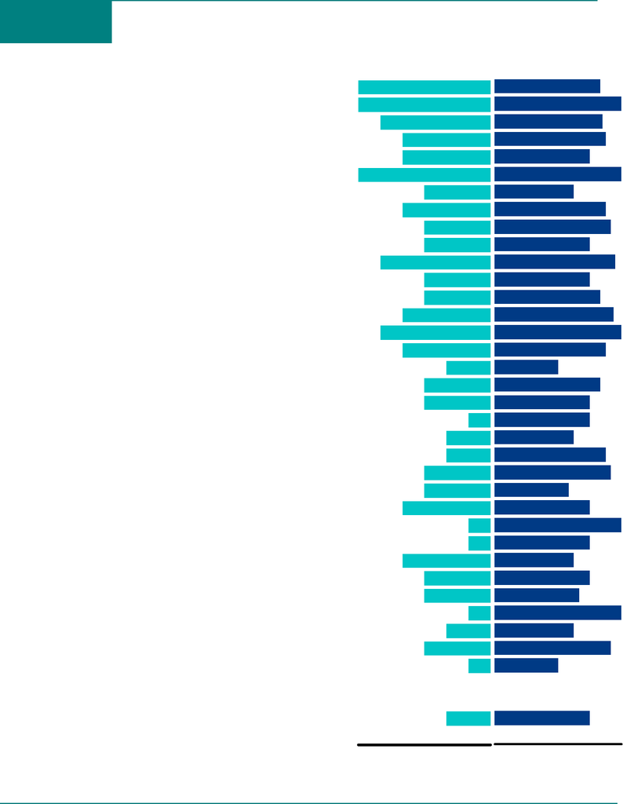

Figure VS-1

Vascular Surgery

Percentage of Programs Citing Each Factor And Mean Importance Rating¹ for Each

Factor in Selecting Applicants to Interview

(N=6)

Avera

g

e Ratin

g

Percent Citin

g

Facto

r

¹ Ratings on a scale from 1 (not at all important) to 5 (very important).

* DO seniors/graduates only.

** International Medical Graduates only.

1

2

3 4

5

4.3

5.0

4.4

4.5

4.0

5.0

3.5

4.5

4.7

4.0

4.8

4.0

4.3

4.8

5.0

4.5

3.0

4.3

4.0

4.0

3.5

4.5

4.7

3.3

4.0

5.0

4.0

3.5

4.0

3.7

5.0

3.5

4.7

3.0

4.0

100% 50% 0%

100%

100%

83%

67%

67%

100%

50%

67%

50%

50%

83%

50%

50%

67%

83%

67%

33%

50%

50%

17%

33%

33%

50%

50%

67%

17

%

17

%

67%

50%

50%

17

%

33%

50%

17%

0%

0%

33%

0%

USMLEStep1score

Lettersofrecommendationinthespecialty

USMLEStep2CKscore

PersonalStatement

MedicalStudentPerformanceEvaluation(MSPE/Dean'sLetter)

Perceivedcommitmenttospecialty

Gradesinrequiredclerkships

Auditionelective/rotationwithinyourdepartment

AnyfailedattemptinUSMLE

Classranking/quartile

Personalpriorknowledgeoftheapplicant

Leadershipqualities

Gradesinclerkshipindesiredspecialty

Evidenceofprofessionalismandethics

Perceivedinterestinprogram

PassingUSMLEStep2CS

Otherlifeexperience

COMLEX‐USALevel1score*

AlphaOmegaAlpha(AOA)membership

AnyfailedattemptinCOMLEX‐USA*

Volunteer/extracurricularexperiences

COMLEX‐USALevel2ClinicalEvaluation(CE)score*

Consistencyofgrades

Awardsorspecialhonorsinclinicalclerkships

Graduateofhighly‐regardedmedical(MD/DO)school

Evidenceofcontinuousmedicaleducationwithoutgaps

GoldHumanismHonorSociety(GHHS)membership

Awardsorspecialhonorsinclerkshipindesiredspecialty

PassingCOMLEX‐USALevel2PerformanceEvaluation*

Demonstratedinvolvementandinterestinresearch

ApplicantwasflaggedwithMatchviolationbytheNRMP

Visastatus**

Awayrotationinyourspecialtyatanotherinstitution

Fluencyinlanguagespokenbyyourpatientpopulation

Interestinacademiccareer

Awardsorspecialhonorsinbasicsciences

USMLEStep3score

COMLEX‐USALevel3score*

NRMP Program Director Survey Results, 2020

164